# Project 2: Predicting how NBA players win?

## 1. Introduction

### b. Quick description of the dataset(s)

The two datasets chosen for this project represent data for NBA players for the 2021-22 regular season. Each row in both datasets represent a NBA player that played minutes during the 2021-22 regular season. The `pergame` dataset provides per game data on various variables, such as points per game and minutes played per game for each player. The `advancedstats` dataset provides various advanced metrics for players, such as usage rate and win shares.

Both datasets were acquired from “Basketball Reference”, a website that collects and sorts data from different basketball leagues and teams. Here are the links to where the datasets were obtained from.

https://www.basketball-reference.com/leagues/NBA_2022_per_game.html#per_game_stats https://www.basketball-reference.com/leagues/NBA_2022_advanced.html#advanced_stats

These datasets were chosen because I am an avid NBA fan and I wanted to see if there were certain statistics that correlated to being a better basketball (more specifically, NBA) player.

I expect certain trends to stand out between variables including playing more minutes and scoring more points correlating to greater win shares for each player.

The `pergame` and `advancedstats` datasets will be joined together to create the final dataset, `NBAfinal`. The datasets are already tidy prior to merging and we will be using the same dataset as the one used in Project 1.

```r
# Import datasets from Project 1
library(readr)

pergame <- read_csv("/home/ssm3484/SDS322E/Project1/pergamedata.txt")
advancedstats <- read_csv("/home/ssm3484/SDS322E/Project1/advancedstatsdata.txt")

NBA <- left_join(pergame, advancedstats, by = c("Rk", "Player", "Pos", "Age", "Tm", "G", "Player-additional"), suffix = c(".game", ".total")) %>%
  select(!"...20" & !"...25")

NBAfinal <- NBA %>%
  select(Player, Tm, Pos, PTS, MP.game, TOV, "TrueShootingPercent" = "TS%", "UsageRate" = "USG%", WS) %>%
  mutate(TrueShootingPercent = TrueShootingPercent * 100) %>%
  filter(PTS > 10)
```

```r
# First look at the final dataset
head(NBAfinal)
```

```
## # A tibble: 6 × 9
##   Player                   Tm    Pos     PTS MP.game   TOV TrueS…¹ Usage…²    WS
##   <chr>                    <chr> <chr> <dbl>   <dbl> <dbl>   <dbl>   <dbl> <dbl>
## 1 Bam Adebayo              MIA   C      19.1    32.6   2.6    60.8    25     7.2
## 2 LaMarcus Aldridge        BRK   C      12.9    22.3   0.9    60.4    22.4   3.1
## 3 Nickeil Alexander-Walker TOT   SG     10.6    22.6   1.4    47.5    24.1   0.1
## 4 Grayson Allen            MIL   SG     11.1    27.3   0.7    60.9    15.2   4.2
## 5 Jarrett Allen            CLE   C      16.1    32.3   1.7    69.8    18.1   8.5
## 6 Giannis Antetokounmpo    MIL   PF     29.9    32.9   3.3    63.3    34.9  12.9
## # … with abbreviated variable names ¹TrueShootingPercent, ²UsageRate
```

### c. Research Question

Can points scored per game (PTS/PPG), minutes played per game (MP.game), and true shooting percentage (TrueShootingPercent) predict the number of win shares (WS) a player has for the season?

## 2. Exploratory Data Analysis

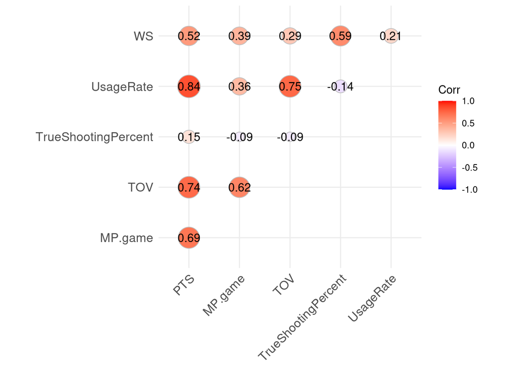

```r
# creates a correlation matrix to show relationship between variables
ggcorrplot(cor(NBAfinal %>% select(PTS, MP.game, TOV, TrueShootingPercent, UsageRate, WS)),
           type = "upper",
           lab = TRUE,
           method = "circle")
```

The variables that most correlated are usage rate with both points and turnovers per game at correlation ratios at .84 and .75, respectively. This makes sense as players who are used more often on the court will ultimately score more points and potentially lose the ball more often. The variables that are the least correlated are true shooting percentage with minutes played and turnovers committed. This makes sense as how many minutes you play or how often you lose the ball isn’t indicative of how well you shoot the ball. The variables that are most correlated with win shares, however, are points per game and true shooting percentage which is understandable as scoring is primary way for teams to win basketball games.

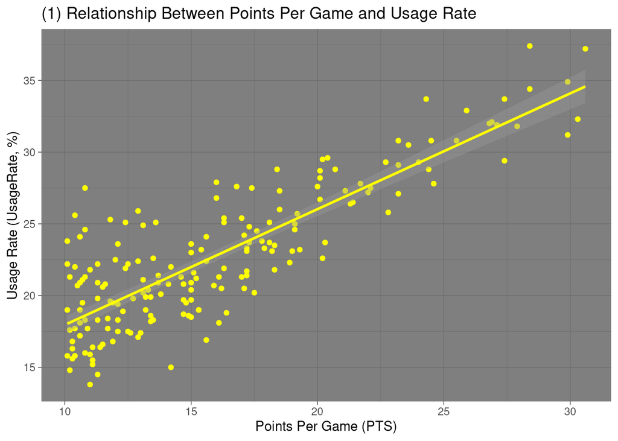

```r
# Visualization 1; displays relationship between usage rate and points per game
ggplot(NBAfinal, aes(x = PTS, y = UsageRate)) +
  geom_point(color = "yellow") +
  labs(title = "(1) Relationship Between Points Per Game and Usage Rate",
       x = "Points Per Game (PTS)",
       y = "Usage Rate (UsageRate, %)") +
  stat_smooth(method = "lm",
              formula = y ~ x,
              geom = "smooth",
              color = "yellow") +
  scale_y_continuous(breaks = seq(10, 50, 5)) +
  scale_x_continuous(breaks = seq(10, 50, 5)) +
  theme_dark()
```

The plot depicts the relationship between the average number of points a player scores per game and how often he is used on the court (basically how often he impacts the plays in the game). The graph shows a strong, positive correlation between the two variables. This means that the more points a player scores, the higher his usage rate will be.

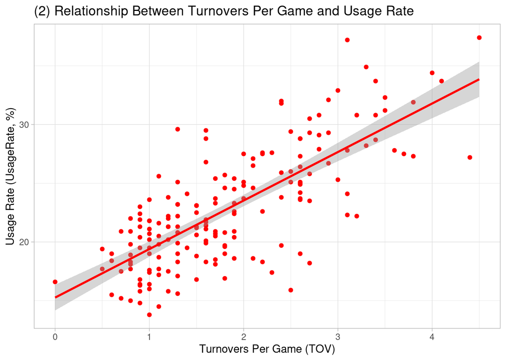

```r
# Visualization 2; displays relationship between usage rate and turnovers per game
ggplot(NBAfinal, aes(x = TOV, y = UsageRate)) +
  geom_point(color = "red") +
  labs(title = "(2) Relationship Between Turnovers Per Game and Usage Rate",
       x = "Turnovers Per Game (TOV)",
       y = "Usage Rate (UsageRate, %)") +
  stat_smooth(method = "lm",
              formula = y ~ x,
              geom = "smooth",
              color = "red") +
  theme_light()
```

The plot depicts the relationship between the number of turnovers a player commits per game and his usage rate for the season. The graph shows a positive correlation between TOV and UsageRate. Meaning that a player with a high usage rate will be more likely to commit more turnovers in a game (more chances to lose the ball if used in plays more often).

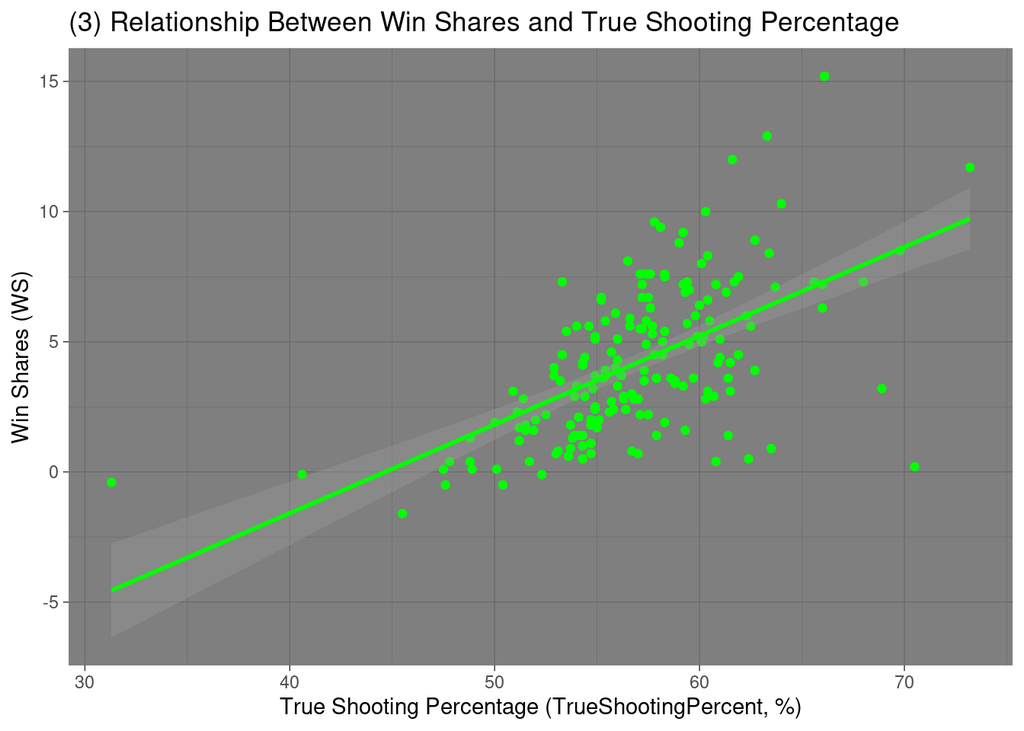

```r
# Visualization 3; displays relationship between win shares and true shooting percentage
ggplot(NBAfinal, aes(x = TrueShootingPercent, y = WS)) +
  geom_point(color = "green") +
  labs(title = "(3) Relationship Between Win Shares and True Shooting Percentage",
       x = "True Shooting Percentage (TrueShootingPercent, %)",
       y = "Win Shares (WS)") +
  stat_smooth(method = "lm",
              formula = y ~ x,
              geom = "smooth",
              color = "green") +
  theme_dark()
```

The graph depicts how true shooting percentage is correlated with the number of win shares a player receives for the season. After a player has about a 50% true shooting percenatge, there is a strong, positive correlation between the two variables. This shows that the better a player shoots the ball, the more win shares (how many wins they earned for their teams in a season) they will recieve.

## 3. Prediction and Cross-Validation

### a. Train the model

```r
# Fit all the data into a linear regression model
fit_linear <- lm(WS ~ PTS + MP.game + TrueShootingPercent, data = NBAfinal)
summary(fit_linear)
```

```
##
## Call:
## lm(formula = WS ~ PTS + MP.game + TrueShootingPercent, data = NBAfinal)
##
## Residuals:
##     Min      1Q  Median      3Q     Max
## -6.5234 -1.0563  0.0413  1.1147  5.8556
##
## Coefficients:
##                      Estimate Std. Error t value Pr(>|t|)
## (Intercept)         -21.63301    2.08248 -10.388  < 2e-16 ***
## PTS                   0.14228    0.03993   3.563 0.000470 ***
##  [ reached getOption("max.print") -- omitted 2 rows ]
## ---
## Signif. codes:  0 '***' 0.001 '**' 0.01 '*' 0.05 '.' 0.1 ' ' 1
##
## Residual standard error: 1.906 on 179 degrees of freedom
## Multiple R-squared:  0.5674, Adjusted R-squared:  0.5602
## F-statistic: 78.27 on 3 and 179 DF,  p-value: < 2.2e-16
```

Formula for the linear model: $\widehat{WS} = -21.63301 + 0.14228 * PTS + 0.15508 * MP.game + 0.33171 * TS\%$

Calculate the Root Mean Squared Error (RMSE) to gauge the performance of the model.

```r
# Calculate RMSE to determine the performance of the linear regression model
sqrt(mean(resid(fit_linear)^2))
```

```
## [1] 1.885158
```

The RMSE is 1.885158, where a lower score closer to 0 is ideal. We will compare this value with the RMSE found from cross-validation next.

### b. Perform cross-validation

```r
# Perform 10-fold cross-validation on the linear regression of our dataset
linear_cv <- train(WS ~ PTS + MP.game + TrueShootingPercent,
      data = NBAfinal ,
      method = "lm",
      trControl = trainControl(method = "cv", number = 10))
linear_cv
```

```
## Linear Regression
##
## 183 samples
##   3 predictor
##
## No pre-processing
## Resampling: Cross-Validated (10 fold)
## Summary of sample sizes: 166, 165, 164, 164, 166, 165, ...
## Resampling results:
##
##   RMSE      Rsquared   MAE
##   1.915646  0.5929406  1.493547
##
## Tuning parameter 'intercept' was held constant at a value of TRUE
```

## 4 & 5. Dimensionality reduction and Clustering

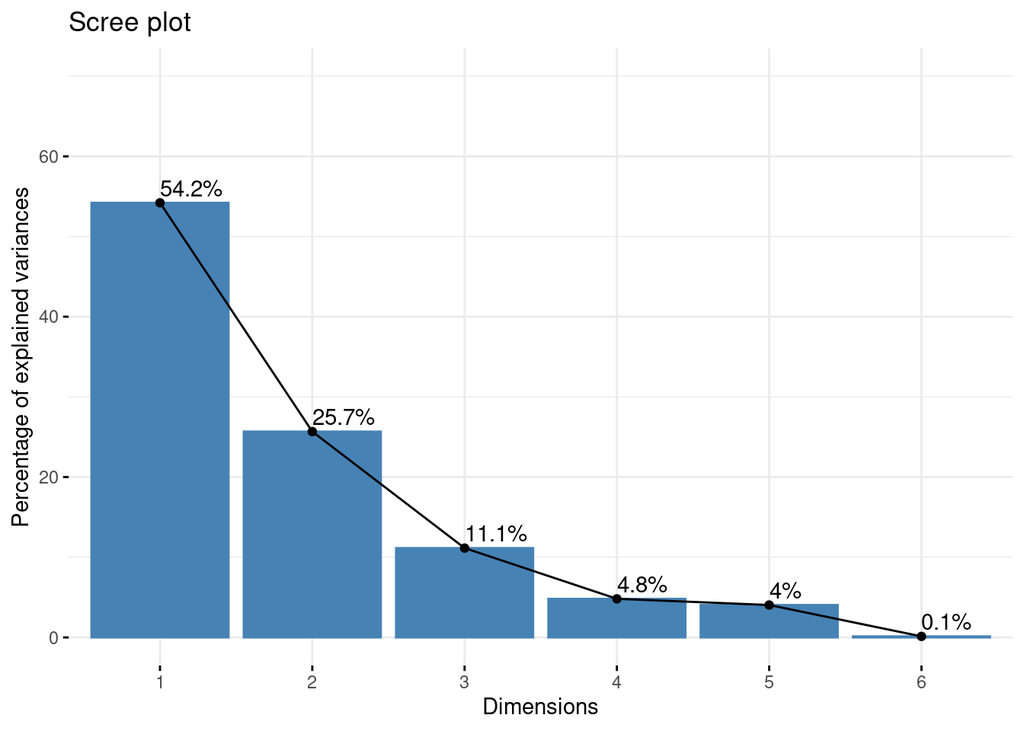

```r
# PCA
# scale data
NBA_scaled <- NBAfinal %>%
  select_if(is.numeric) %>%
  scale

# perform PCA
pca <- NBA_scaled %>%
  prcomp
# finds the efficient number of PCs to use
fviz_eig(pca, addlabels = TRUE, ylim = c(0, 70))
```

```r
# displays contributions of each variable for each PC
get_pca_var(pca)$coord %>% as.data.frame
```

```
##          Dim.1      Dim.2       Dim.3      Dim.4      Dim.5      Dim.6
## PTS -0.9634013 0.03117804 -0.09699038 0.06287808 -0.2324709 0.05901161
##  [ reached 'max' / getOption("max.print") -- omitted 5 rows ]
```

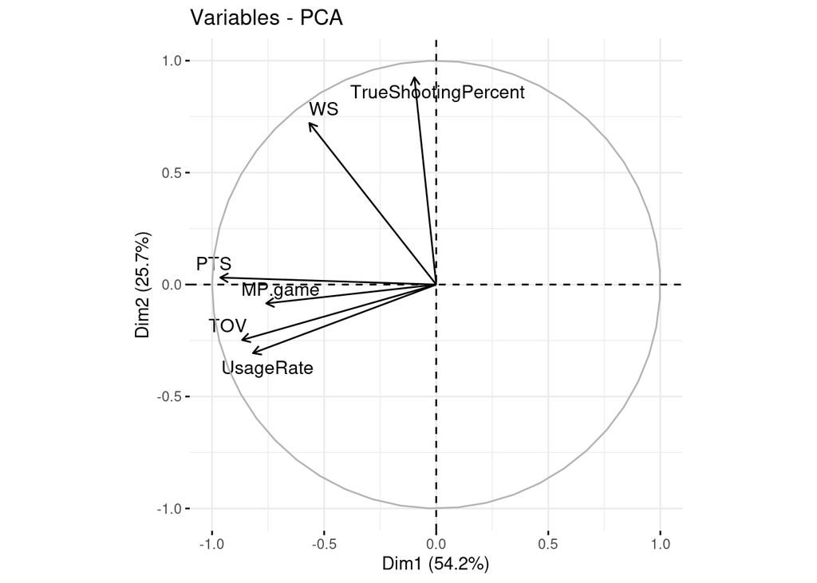

```r
# visualizes the contributions on each variable on a graph
fviz_pca_var(pca, col.var = "black",
             repel = TRUE)
```

The first 2 PCs should be retained as they add up to account for 79.9% of the variation in the data (80% target). Most of the variables in the data (besides TOV) are positively correlated to player success. In other words, the more of each variable a player has, the greater of a player he his. Therefore, since the values for the first PC are all negative, the lower the value for the first PC, the better the player. Since the second dimension values are split between positive and negative values, the value of PC 2 does not really tell us who is a great player or not.

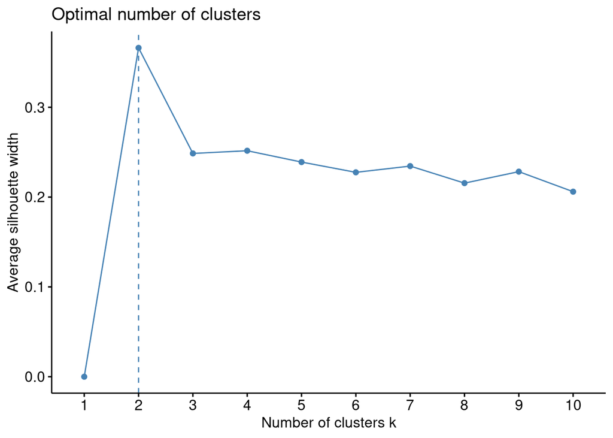

```r
# Perform clustering using kmeans()
# finds appropriate number of clusters to use
fviz_nbclust(NBA_scaled, kmeans, method = "silhouette")
```

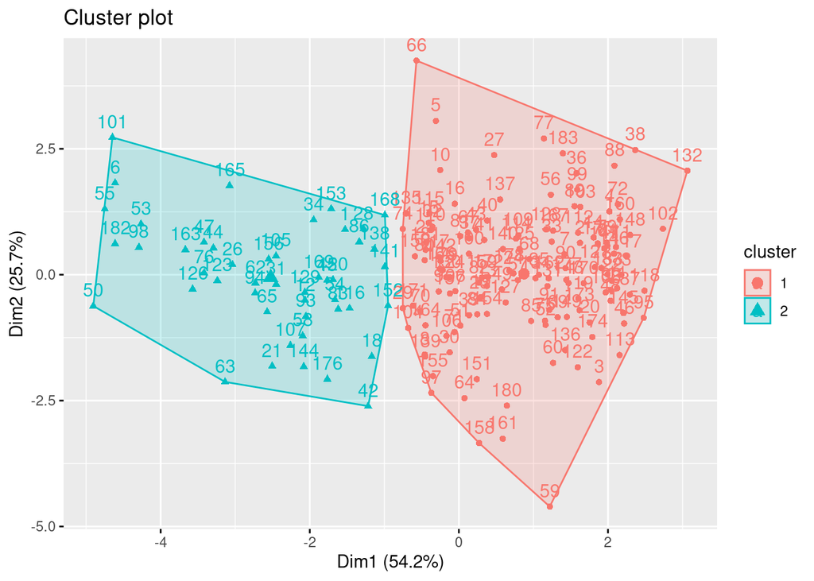

```r
# performs kmeans clustering
kmeans_results <- NBA_scaled %>%
  kmeans(centers = 2)

# visualizing each cluster
fviz_cluster(kmeans_results, data = NBA_scaled)
```

```r
# provides summary statistics for each cluster
NBAfinal %>%
  select_if(is.numeric) %>%
  na.omit %>%
  mutate(cluster = as.factor(kmeans_results$cluster)) %>%
  group_by(cluster) %>%
  summarize_all(mean)
```

```
## # A tibble: 2 × 7
##   cluster   PTS MP.game   TOV TrueShootingPercent UsageRate    WS
##   <fct>   <dbl>   <dbl> <dbl>               <dbl>     <dbl> <dbl>
## 1 1        13.6    28.4  1.45                56.7      20.7  3.47
## 2 2        23.2    34.4  2.95                57.7      29.0  6.23
```

Based on the silhouette width, the optimal number of clusters we will choose is 2. After grouping by clusters, it seems that players in cluster 2 are better players as they have greater averages for each variable than the players in cluster 1 (as discussed earlier, the more of a variable, the better the player). Cluster 2 observations have averages of 23 points per game, 29.02% in usage, and 6.23 win shares which is all greater (and better for a player’s greatness) than cluster 1 players/observations.

Based on the cluster plot, cluster 2 players have lower average PC 1 values than cluster 1 players, meaning that better players have lower PC 1 values, which is a similar conclusion drawn from the PCA analysis above.

## 6. Discussion

When answering the research question, I believe that we can use PPG, minutes played, and TS% to predict win shares. Based on the formula of fitting the data into the linear regression model, the more points scored, minutes played, and being an efficient scorer leads to having more win shares awarded to the player. This can be seem in Visualization 3, where there is a positive correlation between TS% and WS.

Furthermore, it was discovered that all numeric variables positively correlated to not only having greater win shares, but correlated to being a better player based on cluster 2 having a lower average PC 1 value and higher average variable values. The challenging part of this project was interpreting the values and visualizations of the dimensional reduction analysis, but it was eventually figured out. I learned that all types of data can have patterns and that data analysis is a way to extract those patterns.

*Acknowledgments: BasketballReference for the datasets*